# Chapter 15: Probability and Inference in Practice

The Practice of Statistics in the Life Sciences by Brigitte Baldi and David S. Moore

Instructor: Ali Raisolsadat

Part III: Foundations of Inference

# 15 Chapter 15

## 15.1 Inference in Practice

Chapters 9 through 12 built probability models: rules for events, random variables and the Normal, binomial and Poisson distributions. Chapters 13 and 14 used those models to describe how a statistic varies from sample to sample and introduced confidence intervals and hypothesis tests for a population mean.

This chapter connects the two halves. Every confidence interval and every $P$-value is a probability calculation from a distribution. Once that connection is clear, we can ask the practical questions that decide whether an inferential conclusion deserves to be trusted:

1. Where did the data come from?
2. Does the probability model fit the data and the study design?
3. How much random uncertainty remains in the estimate?
4. How large is the estimated effect, and does it matter in context?
5. What errors could the decision produce, and how likely are they?
6. Was the study large enough, and was the analysis planned before the data were examined?

> **Central idea**

> Probability describes what data could occur under a model. Inference compares the observed data with those model-based possibilities. Statistical methods are trustworthy when the model fits the study and the conclusions remain within the limits of the design.

The chapter follows the order of those questions: the probability foundations (15.2), the conditions that connect a model to a study (15.3), how confidence intervals behave (15.4), how tests turn distributions into $P$-values (15.5), how to interpret significance (15.6), the errors a test can make and its power (15.7) and how to plan the size of a study (15.8).

## 15.2 Probability as the Foundation of Inference

The probability chapters and the inference chapters address different stages of the same reasoning process.

- A **probability model** starts with a proposed population or chance mechanism and describes possible outcomes.
- A **sampling distribution** describes how a statistic would vary across repeated samples drawn by the same method.
- **Statistical inference** starts with observed sample data and uses the sampling distribution to evaluate possible population values.

The direction of the reasoning changes, but the probability rules do not.

> **Probability-to-inference connection**

> Probability asks what data could occur under a model. Inference asks whether the observed data are reasonably compatible with that model.

### 15.2.1 Parameters and Statistics

A population parameter is fixed for the population being studied, although its value is usually unknown. A sample statistic depends on the selected observations and therefore changes from sample to sample.

| Scientific quantity | Population parameter | Sample statistic |
| --- | --- | --- |
| Mean of a quantitative variable | $\mu$ | $\bar{x}$ |
| Probability of a binary outcome | $p$ | $\hat p$ |
| Event rate per unit of exposure | $\lambda$ | Observed rate or event count |

Before the sample is selected, the statistic is a random variable. After the sample has been observed, the statistic becomes a known number. Inference uses the observed value while accounting for the statistic’s pre-sampling variability.

### 15.2.2 Population Distributions and Sampling Distributions

The population distribution and the sampling distribution describe different objects.

- The **population distribution** describes individual values or outcomes.
- The **sample distribution** describes the observations in one collected sample.
- The **sampling distribution** describes a statistic across all possible samples of the same size drawn by the same process.

For example, individual body temperatures may have population standard deviation $\sigma$. The sample mean of $n$ independent temperatures has standard deviation

$$\sigma_{\bar X}=\frac{\sigma}{\sqrt{n}}$$

This smaller standard deviation is the standard deviation of the sampling distribution of $\bar X$. It measures the sample-to-sample variation relevant to inference. (When $\sigma$ must be estimated from the data, the estimated version is called the **standard error**; in this chapter $\sigma$ is treated as known.)

### 15.2.3 The Probability-to-Inference Process

| Stage | Question | Statistical object |
| --- | --- | --- |
| Probability model | What outcomes could occur if the model were correct? | Normal, binomial or Poisson distribution |
| Sampling distribution | How would a statistic vary across repeated samples? | Distribution of $\bar x$, $\hat p$ or a count |
| Inference | Is the observed statistic plausible under a stated population claim? | Confidence interval or $P$-value |
| Practical conclusion | What does the evidence support in the study setting? | Contextual conclusion with limitations |

Every inferential conclusion is conditional on the probability model and on the way the data were collected.

### 15.2.4 Probability Rules Used in Inference

Several familiar probability rules appear directly in confidence intervals and tests.

1. **Complement rule**

   $$P(Z\ge z)=1-P(Z<z)$$

   Upper-tail probabilities often use this form. It also gives $P(\text{at least one}) = 1 - P(\text{none})$, which we use for multiple testing in Section 15.6.
2. **Addition of disjoint events**

   A two-sided test combines probability from two non-overlapping tails.
3. **Conditional probability**

   A $P$-value has the form

   $$P(\text{result at least as extreme as observed}\mid H_0)$$

   This probability is not the reverse conditional probability $P(H_0\mid\text{data})$.
4. **Independence**

   Observations are independent when knowing the value of one observation does not change the probabilities for another. Standard errors, the multiplication rule and exact binomial or Poisson probabilities all rely on this assumption.

### 15.2.5 Matching the Distribution to the Response

The response variable and study design guide the choice of a probability model.

| Response | Possible model | Parameter of interest |
| --- | --- | --- |
| Continuous measurement | Normal population model or an approximately Normal sampling distribution | Mean $\mu$ |
| Number of successes in $n$ trials | Binomial model | Success probability $p$ |
| Number of events in fixed exposure | Poisson model | Event rate $\lambda$ |

The model describes more than the shape of a distribution. A binomial model assumes a fixed number of trials, two possible outcomes, independent trials and a common success probability. A Poisson model assumes events occur independently at a stable rate over the defined exposure, without unexplained clustering.

### 15.2.6 The Normal Distribution in Inference

Chapter 11 used $z$-scores to convert an observation into an area under the Standard Normal curve. Inference applies the same standardization to a **statistic** instead of an individual observation:

$$z=\frac{\text{statistic}-\text{model value of its mean}}{\text{standard
deviation of the statistic}}$$

For the sample mean, the standard deviation of the statistic is $\sigma/\sqrt{n}$. It plays the role that $\sigma$ played for individual observations.

The same Standard Normal areas then serve two purposes:

- **Central areas** give critical values for confidence intervals. The middle $95\%$ lies between $-1.96$ and $1.96$.
- **Tail areas** measure how unusual a test statistic is under $H_0$.

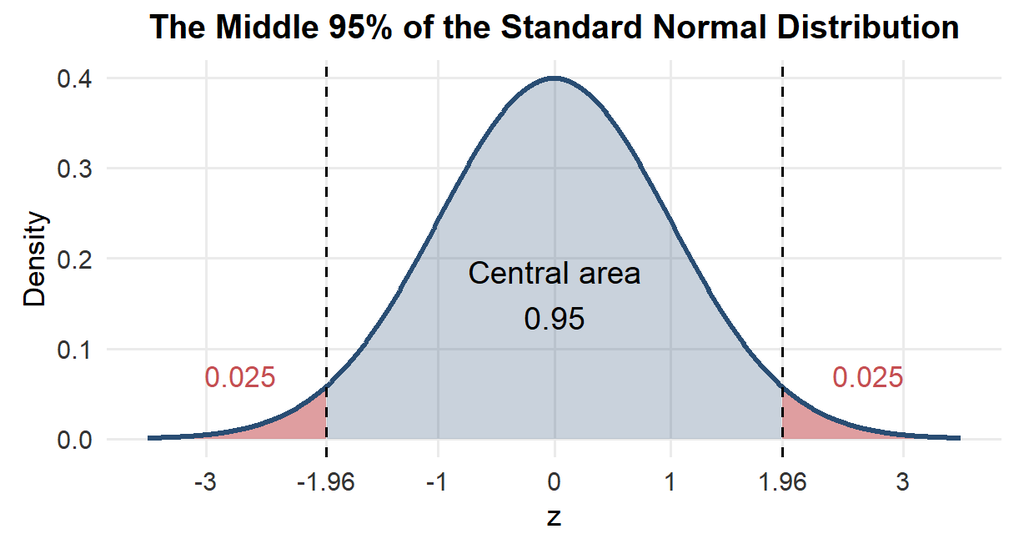

### 15.2.7 Exact Probabilities and Normal Approximations

An inferential probability may be calculated directly from a discrete model or approximated using a Normal distribution.

- An **exact binomial or Poisson calculation** retains the original discrete model.
- A **Normal approximation** replaces the discrete or non-Normal sampling distribution with a Normal model when the approximation conditions are adequate.

The word *exact* refers to the calculation under the assumed probability model. If the model does not fit the study process, an exact calculation can still give a misleading conclusion.

For a binomial count, the common first-year condition for a Normal approximation is

$$np\ge10
\qquad\text{and}\qquad
n(1-p)\ge10$$

For a sample mean, the population shape and the sample size determine whether the Central Limit Theorem provides an adequate approximation. Section 15.5 compares an exact binomial $P$-value with its Normal approximation.

## 15.3 Conditions for Inference in Practice

Every inferential procedure has conditions that connect its mathematical model to the study. A calculation can be numerically correct and still lead to an unreliable conclusion when those conditions do not fit the data.

Two broad questions guide the assessment:

1. **Where did the data come from?**
2. **What is the shape of the population or sampling distribution?**

The first question concerns study design. The second concerns the probability model used by the procedure.

### 15.3.1 The One-Sample $z$ Procedures

Chapter 14 considered inference about a population mean $\mu$ under these conditions:

- The observations came from a simple random sample (or a defensible random process)
- The observations are independent
- The population distribution is Normal, or the sampling distribution of $\bar{x}$ is approximately Normal
- The population standard deviation $\sigma$ is known

Under these conditions, the confidence interval for $\mu$ is

$$\bar{x}
\pm
z^*\frac{\sigma}{\sqrt{n}}$$

and the test statistic for $H_0:\mu=\mu_0$ is

$$z
=
\frac{\bar{x}-\mu_0}{\sigma/\sqrt{n}}$$

These are called **$z$ procedures** because they use the Standard Normal distribution.

Knowing the population standard deviation is unusual in real applications. Chapter 17 replaces $\sigma$ with the sample standard deviation $s$ and introduces the $t$ procedures. The practical questions in this chapter about study design, model conditions and interpretation remain the same.

### 15.3.2 Where the Data Come From

Statistical inference uses probability to describe how a statistic would vary over repeated samples or treatment assignments. This reasoning has a clear foundation when chance enters the study design.

Two forms of randomization play different roles.

| Design feature | How chance is used | Main conclusion supported |
| --- | --- | --- |
| Random sampling | Individuals are selected from a population by chance | Generalization from the sample to the sampled population |
| Random assignment | Experimental units are assigned to treatments by chance | Stronger evidence for a causal treatment effect |

A study can use one, both or neither form of randomization.

- A random sample without random assignment may support population generalization but not a causal conclusion
- A randomized experiment using volunteers may support a causal comparison for the participants but may not represent a broader population
- A convenience sample in an observational study generally supports neither broad generalization nor a strong causal claim

The conclusion should match the design actually used.

### 15.3.3 Acting as Though the Data Were Random

Researchers sometimes apply standard inferential procedures to data that did not come from a true probability sample or randomized experiment. In that situation, the numerical calculation treats the data as though the probability model applies.

The resulting conclusion depends on subject-matter reasoning:

- Are the sampled individuals plausibly similar to the intended population for the variable being studied?
- Could the recruitment method systematically exclude important groups?
- Could the individuals who chose to participate differ from those who did not?
- Could the measurement setting affect the recorded values?

There is no formula that repairs a biased sampling process. When random selection is absent, uncertainty extends beyond the reported standard error.

### 15.3.4 Example 15.1: The Neurobiologist and the Sociologist

Two researchers recruit students from introductory courses at one university.

**Neurobiology study:** A neurobiologist studies how people with normal vision respond to an optical illusion. Basic visual-processing mechanisms may be similar across many groups. Subject-matter knowledge may therefore support a cautious interpretation beyond the specific class, even though the students are not an actual random sample of all people with normal vision.

**Sociology study:** A sociologist studies attitudes toward the use of human participants in scientific research. Age, education, field of study, family background and campus culture may all affect these attitudes. Students in one sociology class are unlikely to represent all adults or even all university students.

The sampling method is similar in the two studies, but the plausibility of broader generalization differs because the variables and scientific questions differ.

> **Main lesson**

> Whether a convenience sample can support a broader conclusion depends partly on how the selection process could relate to the variable being studied.

### 15.3.5 Additional Study-Design Examples

Three studies from Chapter 14 illustrate different relationships between the sample and the intended population.

| Study | Data source | Assessment |
| --- | --- | --- |
| Heights in NHANES | A complex multistage probability sample | The sample is broadly representative, but a formal analysis should account for the complex design |
| IQ scores in a school district | A random sample of seventh-grade girls in the district | The design supports inference to the stated district population |
| Blood phosphorus measurements | Random medical records from one laboratory in Ohio | The sample may represent a narrow laboratory-related population but not all adults aged $75$ to $79$ |

The phosphorus study has two important limitations. Patients whose blood was tested at one laboratory may differ from the broader population, and laboratory procedures can affect recorded measurements. These limitations restrict generalization even though the records were randomly selected from that laboratory.

The population named in the conclusion should match the population the sampling process can reasonably represent.

### 15.3.6 Independence of Observations

Many introductory formulas assume that the observations are independent. Independence means that knowing one observation does not change the probabilities for another observation under the model.

Dependence can arise when

- Several measurements come from the same individual
- Animals come from the same litter or enclosure
- Patients receive care in the same clinic
- Measurements come from nearby locations or adjacent times
- Participants influence one another’s responses

When a simple random sample is drawn without replacement from a finite population, the observations are technically dependent. The dependence is usually small enough to ignore when the sample represents no more than $10\%$ of the population:

$$n\le0.10N$$

This guideline is often called the **10% condition**. It does not address clustering or repeated measurements. Those forms of dependence require a method that represents the group or repeated-measure structure.

### 15.3.7 Problems That Can Arise After a Good Design

Even a well-designed sample or experiment can encounter difficulties.

**Nonresponse** occurs when selected individuals do not provide data. Nonresponse creates bias when the people who respond differ systematically from those who do not respond.

**Attrition** occurs when participants leave a study before it ends. If departure is related to treatment, health or the outcome being studied, the remaining observations may no longer represent the original groups.

**Measurement error** occurs when the recorded value differs from the quantity the study intended to measure. Poor calibration, inconsistent procedures and inaccurate self-reports can introduce error.

**Protocol deviations** occur when participants do not follow their assigned treatment or researchers do not apply the planned procedure consistently.

These problems are not automatically represented in a standard confidence interval or $P$-value.

### 15.3.8 Complex Sampling Designs

A simple random sample gives every possible sample of size $n$ the same chance of selection. Large surveys often use more complicated designs, such as

- Stratified sampling
- Cluster sampling
- Multistage sampling
- Unequal selection probabilities

These designs can be efficient and scientifically appropriate, but the analysis must account for how the sample was selected. Treating a complex design as an SRS can produce incorrect standard errors and confidence intervals.

The design and the analysis should be planned together.

### 15.3.9 The Population Model and Sample Size

Parametric inference begins with a probability model for the population. For inference about a mean, the one-sample $z$ procedures use the distribution of the sample mean. The relevant condition is therefore the shape of the **sampling distribution of $\bar{x}$**, not necessarily the exact shape of the individual observations.

If the population is Normal, then

$$\bar{X}
\sim
N\left(
\mu,
\frac{\sigma}{\sqrt{n}}
\right)$$

for every sample size $n$. (Following the textbook, the second number in $N(\cdot,\cdot)$ is a standard deviation.)

If the population is not Normal, the Central Limit Theorem often makes the sampling distribution of $\bar{x}$ approximately Normal when the sample size is sufficiently large. How large depends on the population shape:

- With a small sample, strong skewness or outliers can make Normal-based inference unreliable
- A moderate sample is often sufficient when the population is roughly symmetric with light tails
- A strongly skewed or heavy-tailed population may require a large sample or a different method

There is no universal rule that makes $n=30$ sufficient for every population. When the population distribution is unknown, previous research and graphs of the sample data provide useful evidence. A dotplot, histogram or Normal quantile plot can reveal strong skewness, gaps and unusual observations.

### 15.3.10 Small Samples and Outliers

Small samples contain limited information about population shape. A sample of only a few observations may appear roughly symmetric even when the population is not.

Outliers deserve particular attention because the sample mean and sample standard deviation are not resistant. One extreme observation can

- Shift the value of $\bar{x}$
- Increase the value of $s$
- Change a confidence interval
- Alter the test statistic and $P$-value

Before removing an observation, researchers should determine whether it reflects a data-entry error, measurement problem or valid but unusual case. An observation should not be excluded only because its removal makes the analysis more favourable.

### 15.3.11 A Practical Conditions Checklist

Before using an inferential procedure, ask:

1. What population or treatment comparison does the study address?
2. How were individuals selected and, when applicable, assigned to treatments?
3. Are the observations sufficiently independent?
4. Does the probability model match the response and the study process?
5. Are outliers, missing values or measurement problems present?
6. Does the procedure account for the actual sampling or experimental design?

The answers determine whether the standard error, confidence interval and $P$-value have a defensible interpretation. For the rest of the chapter we assume the conditions hold and study how the procedures behave.

## 15.4 How Confidence Intervals Behave

Many confidence intervals have the form

$$\text{estimate}
\pm
\text{margin of error}$$

The margin of error combines a critical value with the standard deviation of the estimate:

$$\text{margin of error}
=
\text{critical value}
\times
\text{standard deviation of the estimate}$$

For the one-sample $z$ interval for a population mean,

$$m
=
z^*\frac{\sigma}{\sqrt{n}}$$

The estimate determines the centre of the interval and the margin of error determines its half-width.

### 15.4.1 From the Sampling Distribution to a Confidence Interval

The interval formula follows from a probability statement about the sample mean. Under the one-sample $z$ model,

$$Z
=
\frac{\bar X-\mu}{\sigma/\sqrt{n}}
\sim N(0,1)$$

The central $95\%$ of the Standard Normal distribution lies between approximately $-1.96$ and $1.96$:

$$P\left(
-1.96
\le
\frac{\bar X-\mu}{\sigma/\sqrt{n}}
\le
1.96
\right)
=0.95$$

Multiplying through by $\sigma/\sqrt{n}$ and rearranging the inequalities places $\mu$ in the centre:

$$P\left(
\bar X-1.96\frac{\sigma}{\sqrt{n}}
\le
\mu
\le
\bar X+1.96\frac{\sigma}{\sqrt{n}}
\right)
=0.95$$

Before sampling, the endpoints are random because they depend on $\bar X$. The parameter $\mu$ is fixed.

### 15.4.2 Long-Run Coverage

A $95\%$ confidence procedure has a long-run coverage rate of $95\%$ under the stated model. If the same sampling process were repeated many times, approximately $95\%$ of the resulting intervals would contain the true parameter and approximately $5\%$ would miss it.

The figure below simulates this process. Forty random samples of $n=31$ IQ scores are drawn from a population with $\mu=100$ and $\sigma=15$, and a $95\%$ interval is computed from each sample.

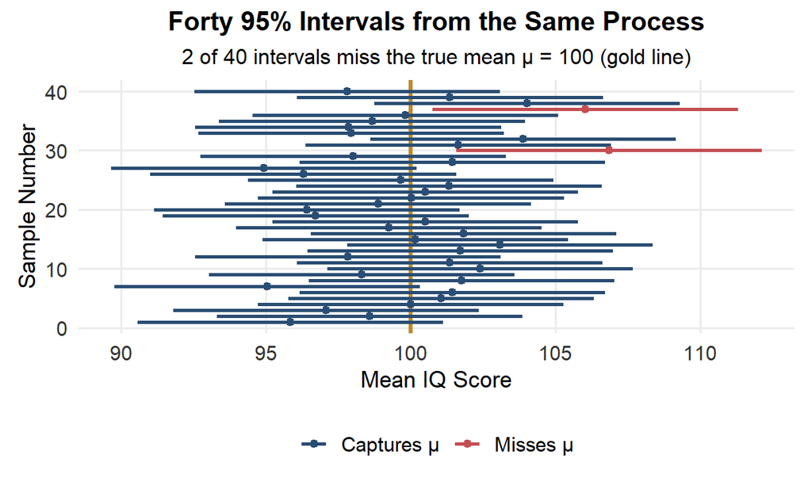

In this simulation, 2 of the $40$ intervals miss $\mu$. Because each interval independently captures $\mu$ with probability $0.95$, the number of misses among $40$ intervals follows a $\operatorname{Bin}(40,0.05)$ distribution with mean $40(0.05)=2$. This is the probability model behind the phrase “95% confident”.

After one sample has been collected, the calculated interval is fixed. Either it contains $\mu$ or it does not. The usual frequentist interpretation refers to the reliability of the procedure rather than a probability assigned to the fixed parameter.

> **Suitable interpretation**

> We are $95\%$ confident that the population parameter lies between the reported endpoints because the method captures the true parameter in approximately $95\%$ of repeated samples under the model conditions.

### 15.4.3 Three Quantities Control the Margin of Error

From

$$m=z^*\frac{\sigma}{\sqrt{n}}$$

three quantities determine the margin of error:

| Quantity | Change | Effect on $m$ |
| --- | --- | --- |
| Confidence level (through $z^*$) | Higher confidence | Larger margin |
| Population variability $\sigma$ | Larger $\sigma$ | Larger margin |
| Sample size $n$ | Larger $n$ | Smaller margin |

The next subsections examine each quantity in turn using the IQ example.

### 15.4.4 Confidence Level and the Critical Value

A confidence interval ideally has both a high confidence level and a small margin of error. With the same data, these goals compete.

| Confidence level | Central area | Area in each tail | Critical value $z^*$ |
| --- | --- | --- | --- |
| $90\%$ | $0.90$ | $0.05$ | $1.645$ |
| $95\%$ | $0.95$ | $0.025$ | $1.960$ |
| $99\%$ | $0.99$ | $0.005$ | $2.576$ |

A higher confidence level includes a larger central area under the Standard Normal curve, so the cutoffs move farther into the tails and $z^*$ increases.

Lowering the confidence level produces a narrower interval, but it also reduces the long-run coverage rate. It does not create additional information in the data.

### 15.4.5 Example 15.2: Confidence Level and Margin of Error

A random sample of $n=31$ seventh-grade girls in a school district has mean IQ score

$$\bar{x}=105.84$$

and IQ scores are assumed to have $\sigma=15$. The standard deviation of $\bar x$ is

$$\frac{\sigma}{\sqrt{n}}
=
\frac{15}{\sqrt{31}}
\approx
2.694$$

For a $95\%$ confidence level,

$$m_{95}
=
1.960\left(\frac{15}{\sqrt{31}}\right)
\approx
5.28
\qquad\Rightarrow\qquad
105.84\pm5.28
=
\boxed{(100.56,\ 111.12)}$$

For a $90\%$ confidence level,

$$m_{90}
=
1.645\left(\frac{15}{\sqrt{31}}\right)
\approx
4.43
\qquad\Rightarrow\qquad
\boxed{(101.41,\ 110.27)}$$

For a $99\%$ confidence level,

$$m_{99}
=
2.576\left(\frac{15}{\sqrt{31}}\right)
\approx
6.94
\qquad\Rightarrow\qquad
\boxed{(98.90,\ 112.78)}$$

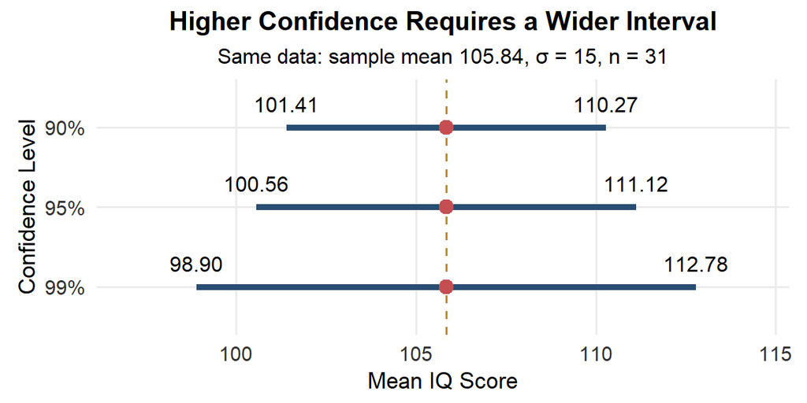

All three intervals are centred at the same sample mean. The higher confidence levels produce wider intervals.

The calculations can be checked with short R commands.

```r
x_bar <- 105.84
sigma <- 15
n <- 31

confidence_levels <- c(0.90, 0.95, 0.99)
z_star <- qnorm((1 + confidence_levels) / 2)
margin_error <- z_star * sigma / sqrt(n)

data.frame(
  confidence_level = confidence_levels,
  z_star = round(z_star, 3),
  margin_error = round(margin_error, 2),
  lower = round(x_bar - margin_error, 2),
  upper = round(x_bar + margin_error, 2)
)
```

```
##   confidence_level z_star margin_error  lower  upper
## 1             0.90  1.645         4.43 101.41 110.27
## 2             0.95  1.960         5.28 100.56 111.12
## 3             0.99  2.576         6.94  98.90 112.78
```

### 15.4.6 Population Variability

The population standard deviation $\sigma$ measures the variability among individual values. The margin of error is directly proportional to $\sigma$: if all other quantities remain fixed, doubling $\sigma$ doubles the margin of error.

A smaller $\sigma$ produces less sample-to-sample variation in $\bar x$; a larger $\sigma$ makes the population mean harder to estimate precisely.

Natural biological variation often cannot be reduced. Measurement-related variation may sometimes be reduced through

- More precise instruments
- Standardized measurement procedures
- Better training and quality control
- Repeated measurements when scientifically appropriate

The value of $\sigma$ used for planning should describe the population and measurement process relevant to the study.

### 15.4.7 Sample Size and the Square-Root Relationship

For fixed values of $z^*$ and $\sigma$,

$$m
\propto
\frac{1}{\sqrt{n}}$$

Larger samples produce more precise estimates, but precision improves according to a square-root relationship.

| Change in sample size | Change in $\sigma/\sqrt{n}$ | Change in margin of error |
| --- | --- | --- |
| $n$ becomes $4n$ | Divided by $2$ | Divided by $2$ |
| $n$ becomes $9n$ | Divided by $3$ | Divided by $3$ |
| $n$ becomes $100n$ | Divided by $10$ | Divided by $10$ |

Doubling the sample size multiplies the margin of error by

$$\frac{1}{\sqrt{2}}
\approx
0.707$$

Therefore, doubling the sample size reduces the margin of error by approximately $29.3\%$, not by $50\%$.

### 15.4.8 Example 15.2 (continued): Increasing the Sample Size

The original $95\%$ margin of error is

$$m_{31}
=
1.960\frac{15}{\sqrt{31}}
\approx
5.28$$

If the sample size increases from $31$ to $62$, then

$$m_{62}
=
1.960\frac{15}{\sqrt{62}}
\approx
3.73$$

The ratio of the margins is

$$\frac{m_{62}}{m_{31}}
=
\sqrt{\frac{31}{62}}
=
\frac{1}{\sqrt{2}}
\approx
0.707$$

Doubling the sample size does not halve the margin of error. A fourfold increase from $31$ to $124$ is required to reduce the original margin by one-half:

$$m_{124}
=
1.960\frac{15}{\sqrt{124}}
\approx
2.64
=
\frac{5.28}{2}$$

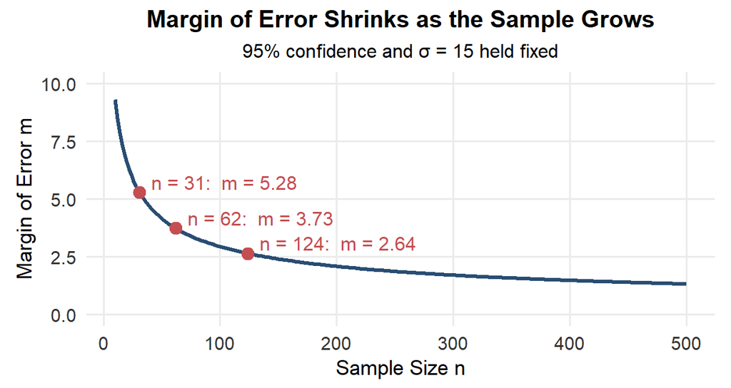

The curve becomes flatter as $n$ increases. When a study already has a large sample, obtaining the same absolute reduction in margin of error requires many additional observations.

The next figure keeps the confidence level fixed at $95\%$ and shows the actual intervals. For the comparison, the centre is held at $105.84$ so that only the width changes. Each interval is $105.84 \pm 1.96(15)/\sqrt{n}$.

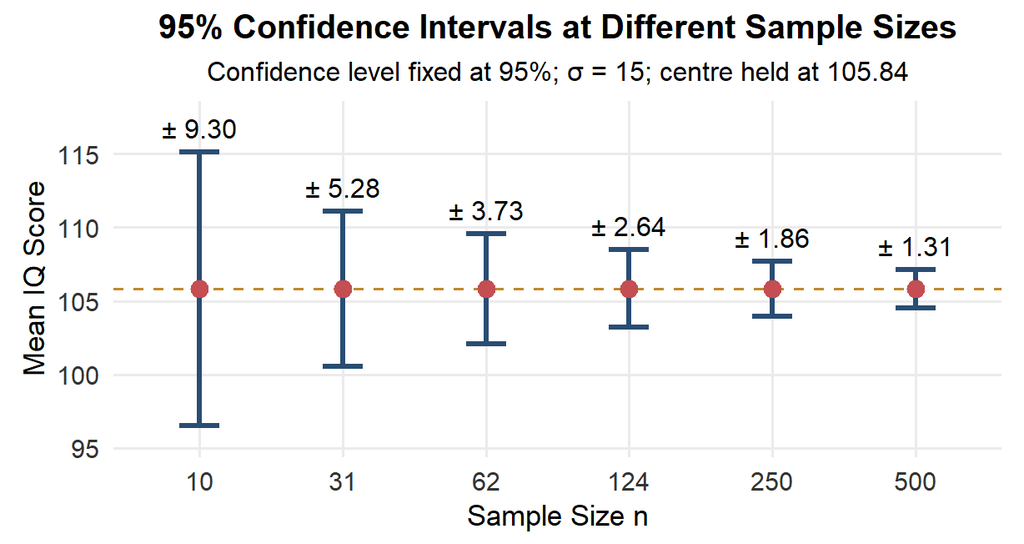

With the confidence level fixed, the long-run capture rate stays at $95\%$ for every sample size. What changes with $n$ is the precision: larger samples produce narrower intervals with the same coverage. In practice, a new sample would also produce a different sample mean, so the centre would move as well.

```r
n_values <- c(10, 31, 62, 124, 250, 500)
margin_values <- qnorm(0.975) * 15 / sqrt(n_values)

data.frame(
  n = n_values,
  margin = round(margin_values, 2),
  lower = round(105.84 - margin_values, 2),
  upper = round(105.84 + margin_values, 2)
)
```

```
##     n margin  lower  upper
## 1  10   9.30  96.54 115.14
## 2  31   5.28 100.56 111.12
## 3  62   3.73 102.11 109.57
## 4 124   2.64 103.20 108.48
## 5 250   1.86 103.98 107.70
## 6 500   1.31 104.53 107.15
```

### 15.4.9 What the Margin of Error Measures

The margin of error describes uncertainty caused by random sampling under the assumed model. It measures how far the statistic may fall from the parameter because different random samples contain different observations.

> **Covered by the margin of error**

> Random sample-to-sample variation generated by the stated sampling process

This limitation follows from the sampling distribution. A sampling distribution describes the variation of a statistic across repeated random samples. It does not describe every way in which a study can go wrong.

### 15.4.10 What the Margin of Error Does Not Measure

The usual margin of error does not include uncertainty or bias caused by

- Undercoverage
- Voluntary response
- Nonresponse
- Leading or ambiguous questions
- Inaccurate self-reports
- Systematic measurement error
- Confounding
- Attrition related to treatment or outcome
- A mismatch between the statistical procedure and the study design

These problems can be more serious than random sampling error.

For example, a public-opinion poll may report a small sampling margin of error even when few selected individuals respond. The calculation measures random variation under the assumed sampling model. It does not show that respondents and nonrespondents have similar opinions.

Similarly, a clinical trial may produce a precise interval for the participants who remain in the study. If participants with severe side effects leave at a higher rate, the usual interval does not measure the bias created by that attrition.

> **Important caution**

> A narrow confidence interval indicates high precision under the model. It does not guarantee that the estimate is accurate or free from bias.

## 15.5 How Hypothesis Tests Behave

A confidence interval uses the sampling distribution to describe plausible values of a parameter. A hypothesis test uses the same kind of distribution in a different way: it assumes one specific parameter value, the null hypothesis, and asks how unusual the observed result would be under that assumption.

### 15.5.1 A $P$-Value Is a Probability from the Null Distribution

The **null distribution** is the sampling distribution of the test statistic when $H_0$ and the model conditions are true. The $P$-value is a tail probability from that distribution:

$$P\text{-value}
=
P(\text{test statistic at least as extreme as observed}\mid H_0)$$

- A small value means that the observed result lies in an unusual part of the null distribution
- A large value means that the observed result remains reasonably compatible with the null model

The calculation evaluates the data under $H_0$. It does not have the reverse form $P(H_0\mid\text{data})$, so it is not the probability that $H_0$ is true.

### 15.5.2 The Test Statistic Locates the Data

For a one-sample $z$ test of a population mean,

$$z
=
\frac{\bar{x}-\mu_0}{\sigma/\sqrt{n}}$$

the numerator is the observed difference from the null value and the denominator is the standard deviation of $\bar x$ expected from random sampling. A value such as $z=2.4$ means that the observed sample mean is $2.4$ standard deviations of $\bar x$ above the null mean.

### 15.5.3 The Alternative Hypothesis Determines the Tail

The alternative hypothesis determines which outcomes count as at least as extreme.

| Alternative hypothesis | Relevant area for the $P$-value |
| --- | --- |
| $H_a:\mu>\mu_0$ | Right tail: $P(Z\ge z_{\text{obs}})$ |
| $H_a:\mu<\mu_0$ | Left tail: $P(Z\le z_{\text{obs}})$ |
| $H_a:\mu\ne\mu_0$ | Both tails: $2P(Z\ge \lvert z_{\text{obs}}\rvert)$ |

For a symmetric null distribution, the two-sided $P$-value adds two equal disjoint tails, so a one-sided $P$-value is exactly one-half of the two-sided $P$-value when the observed effect is in the direction specified by $H_a$.

The direction must be justified by the scientific question before the data are examined. Choosing a one-sided alternative after seeing the sample result makes the evidence appear stronger than the planned analysis permits and does not preserve the intended error rate.

### 15.5.4 The Null Distribution Does Not Have to Be Normal

The logic of a test does not depend on the Normal distribution. Whatever the response, the steps are the same:

1. State $H_0$ and $H_a$ for the parameter
2. Use $H_0$ to fully specify a probability model for the statistic
3. Use $H_a$ to decide which tail counts as “at least as extreme”
4. Add up the probability of the observed outcome and every more extreme outcome

| Outcome | Null model | Practical check |
| --- | --- | --- |
| Continuous measurement | Normal sampling model for $\bar x$ | Study design, distributional shape and variability |
| Binary treatment response | Binomial model for the success count | Independence and a common response probability |
| Disease-event count | Poisson model for the count | Stable rate, constant exposure and no clustering |

The next two examples use discrete models from Chapter 12. For a discrete count, “at least as extreme” means adding the probabilities of individual outcomes.

### 15.5.5 Example 15.3: Exact Binomial Inference for a Treatment Response

A veterinary study evaluates whether a treatment reaches a proposed response probability of $0.80$. Among $60$ independently treated dogs, $41$ show the response defined in the study protocol.

Let $X$ be the number of dogs that respond. The hypotheses are

$$H_0:p=0.80
\qquad
H_a:p<0.80$$

Under the null hypothesis,

$$X\sim\operatorname{Bin}(60,0.80)$$

with expected count $np=60(0.80)=48$. The observed $41$ is below this, which is the direction of $H_a$.

Because the alternative concerns a lower response probability, the outcomes at least as extreme as observed are $41$ or fewer responses. The notation

$$P(X\le41\mid H_0)
=
P(X\le41\mid p=0.80)$$

means that the probability is calculated while treating the null model as true. Each individual probability comes from the binomial formula:

$$P(X=x\mid H_0)
=
\binom{60}{x}(0.80)^x(0.20)^{60-x}$$

The $P$-value adds these probabilities for $x=0,1,\dots,41$:

$$P(X\le41\mid p=0.80)
=
\sum_{x=0}^{41}
\binom{60}{x}(0.80)^x(0.20)^{60-x}
\approx
0.0221$$

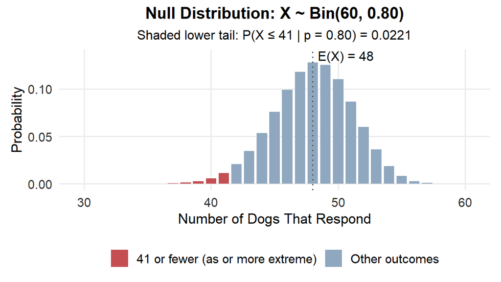

If the null model were correct, a response count of $41$ or fewer would occur in approximately $2.21\%$ of comparable studies. At $\alpha=0.05$, the result is statistically significant and provides evidence that the response probability is below $0.80$.

The conclusion depends on the binomial assumptions:

- Each dog has a response or no response according to the stated definition
- The study includes a fixed number of $60$ trials
- Outcomes are sufficiently independent
- The same response probability is reasonable for the population represented by the study

The exact calculation can be obtained in R with one line.

```r
n_dogs <- 60
p_null <- 0.80
x_observed <- 41

p_value <- pbinom(
  q = x_observed,
  size = n_dogs,
  prob = p_null
)

p_value
```

```
## [1] 0.02206845
```

The argument `q = 41` includes every possible count from $0$ through $41$, which matches the lower-tail event in the summation.

### 15.5.6 Example 15.3 (continued): Exact Versus Normal Approximation

The Normal approximation conditions are satisfied because

$$np=60(0.80)=48\ge10
\qquad\text{and}\qquad
n(1-p)=60(0.20)=12\ge10$$

Under $H_0$, the count has mean $48$ and standard deviation

$$\sqrt{np(1-p)}=\sqrt{60(0.80)(0.20)}=\sqrt{9.6}\approx3.098$$

With a continuity correction, $X\le41$ is approximated by $Y\le41.5$ where $Y\sim N(48,\ 3.098)$:

$$P(X\le41)
\approx
P\left(Z\le\frac{41.5-48}{3.098}\right)
=
P(Z\le-2.10)
\approx
0.0180$$

| Method | $P$-value |
| --- | --- |
| Exact binomial | $0.0221$ |
| Normal approximation with continuity correction | $0.0180$ |

Both methods lead to the same conclusion at $\alpha=0.05$, but they do not give the same number. The approximation is less accurate here because $n(1-p)=12$ is barely above $10$. The exact binomial calculation is preferable when it is readily available.

```r
exact <- pbinom(41, size = 60, prob = 0.80)
approx_cc <- pnorm(41.5, mean = 48, sd = sqrt(60 * 0.80 * 0.20))

round(c(exact = exact, normal_cc = approx_cc), 4)
```

```
##     exact normal_cc
##    0.0221    0.0180
```

### 15.5.7 Example 15.4: Exact Poisson Inference for a Disease Count

A wildlife-health program historically records an average of $12$ confirmed cases of a disease per month. During one month, the program records $20$ cases. Researchers want to determine whether this count is unusually high under the historical-rate model.

Let $X$ be the number of confirmed cases in one month. The hypotheses and null model are

$$H_0:\lambda=12
\qquad
H_a:\lambda>12
\qquad
X\sim\operatorname{Pois}(12)$$

The upper-tail alternative makes counts of $20$ or more at least as extreme as the observed count. For any single count $x$,

$$P(X=x\mid H_0)
=
e^{-12}\frac{12^x}{x!}$$

The upper tail has infinitely many terms, so the complement rule is used:

$$P(X\ge20\mid\lambda=12)
=
1-P(X\le19\mid\lambda=12)
=
1-
\sum_{x=0}^{19}
e^{-12}\frac{12^x}{x!}
\approx
0.0213$$

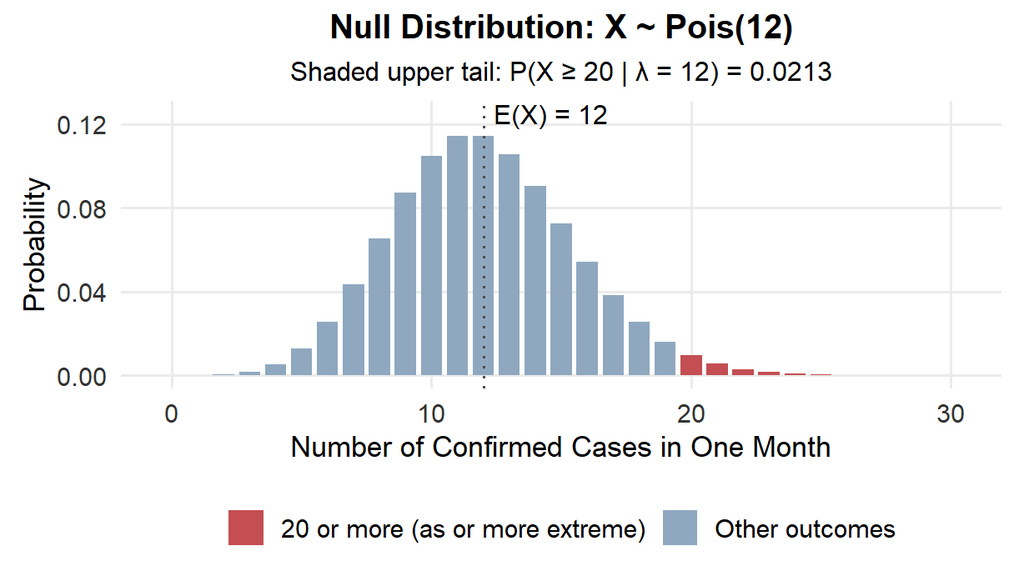

Under the stable-rate model, a monthly count of $20$ or more would occur in approximately $2.13\%$ of months. This result provides evidence against the proposed rate of $12$ cases per month.

The calculation in R also uses the complement:

```r
lambda_null <- 12
x_observed <- 20

p_value <- ppois(
  q = x_observed - 1,
  lambda = lambda_null,
  lower.tail = FALSE
)

p_value
```

```
## [1] 0.02127977
```

Because `lower.tail = FALSE`, R calculates $P(X>19)$. For an integer-valued count, $X>19$ is the same event as $X\ge20$. An equivalent calculation is `1 - ppois(19, lambda = 12)`.

### 15.5.8 Example 15.4 (continued): What the Small $P$-Value Does Not Identify

Before concluding that the underlying disease rate increased, researchers should consider whether the Poisson assumptions and exposure remained reasonable. Possible concerns include

- Seasonal changes in disease occurrence
- Increased testing or surveillance effort
- Clustering within a location or animal group
- A change in the size of the population at risk

The small tail probability shows tension with the stated Poisson model. It does not identify which assumption or rate changed. This is true of every $P$-value: a small value can arise because the null parameter value is wrong, because a model assumption is wrong, or both.

## 15.6 Interpreting Statistical Significance

Examples 15.3 and 15.4 produced small $P$-values. This section asks what such a result does and does not tell us.

### 15.6.1 Evidence Is Continuous

Smaller $P$-values indicate that the observed data are less compatible with the null model. Evidence does not change abruptly at a conventional threshold.

For example, the values

$$P=0.048
\qquad\text{and}\qquad
P=0.052$$

represent nearly the same strength of evidence, even though a fixed rule with $\alpha=0.05$ places them on opposite sides of the decision threshold. By contrast, $P=0.004$ provides substantially stronger evidence against $H_0$ than $P=0.04$.

Reporting the exact $P$-value communicates more information than reporting only whether a result is statistically significant.

### 15.6.2 How Small Must a $P$-Value Be?

The strength of evidence required for a decision depends partly on the setting.

**Plausibility of the null hypothesis:** A well-established claim may require stronger evidence before researchers revise it.

**Consequences of rejection:** A decision involving serious health risks, high costs or an irreversible policy change may require stronger evidence than a preliminary decision to continue investigating a question.

**Quality of the study:** A small $P$-value from biased or poorly measured data does not provide reliable evidence about the intended population question.

Conventional significance levels such as $0.05$ and $0.01$ can support consistent decision rules, but $\alpha=0.05$ should not be treated as a universal boundary between meaningful and meaningless results.

### 15.6.3 What a $P$-Value Is Not

A $P$-value is frequently misinterpreted. It is not

- The probability that $H_0$ is true
- The probability that $H_a$ is true
- The probability that the observed result occurred only by chance
- A measure of effect size or practical importance
- A substitute for checking the study design and model conditions

A large $P$-value means that the observed data remain reasonably compatible with the null model. It does not prove that $H_0$ is true because other parameter values may also be compatible with the data.

### 15.6.4 Statistical Significance Depends on Sample Size

The $z$ statistic can be viewed as

$$z
=
\frac{\bar{x}-\mu_0}
{\sigma/\sqrt{n}}
=
\frac{\text{size of the observed effect}}
{\text{size of chance variation}}$$

The $P$-value therefore depends on three quantities:

1. The observed effect $\bar{x}-\mu_0$
2. The population variability $\sigma$
3. The sample size $n$

As $n$ increases, $\sigma/\sqrt n$ decreases. A very large sample can produce a large test statistic for a small effect. A small sample or a highly variable population may produce weak statistical evidence even when the observed effect is fairly large.

Suppose three studies all observe the same effect, $\bar x-\mu_0=0.30$, with $\sigma=2.4$:

| $n$ | $\sigma/\sqrt{n}$ | $z$ | Two-sided $P$-value |
| --- | --- | --- | --- |
| $25$ | $0.48$ | $0.625$ | $0.532$ |
| $100$ | $0.24$ | $1.25$ | $0.211$ |
| $400$ | $0.12$ | $2.50$ | $0.012$ |

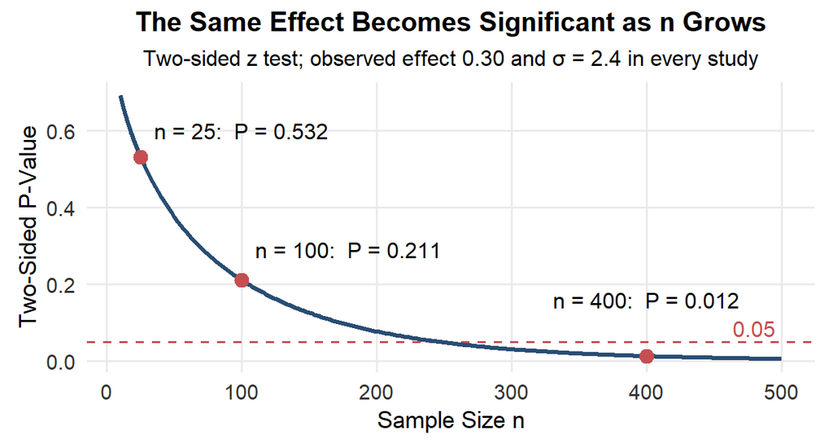

The figure holds the observed effect and population standard deviation fixed while increasing the sample size. The same effect produces a much smaller $P$-value when it is estimated with greater precision. The practical size of the effect has not changed.

Failing to reject $H_0$ does not show that the effect is exactly zero. The study may have had insufficient information to detect an effect. Section 15.7 makes this idea precise through power.

```r
n <- c(25, 100, 400)
z <- 0.30 / (2.4 / sqrt(n))
data.frame(n = n, z = z, p_value = round(2 * pnorm(-z), 3))
```

```
##     n     z p_value
## 1  25 0.625   0.532
## 2 100 1.250   0.211
## 3 400 2.500   0.012
```

### 15.6.5 Statistical Significance and Practical Importance

Statistical significance and practical importance address different questions.

| Question | Relevant information |
| --- | --- |
| Are the data difficult to explain under $H_0$? | $P$-value and model conditions |
| How large might the effect be? | Estimate and confidence interval |
| Is the effect important? | Scientific, clinical or policy context |

A $P$-value does not report the size of an effect. A confidence interval is more informative about the plausible magnitude, but the interval still requires context.

A difference of $0.2$ units may be important for one outcome and negligible for another. Subject-matter knowledge is necessary to identify a meaningful threshold.

### 15.6.6 Example 15.5: Facebook’s Large-Scale Experiment

Facebook conducted a randomized experiment involving $689{,}003$ users. For one week, the platform reduced the amount of positive or negative emotional content from friends that appeared in selected users’ News Feeds. The users’ subsequent posts were then examined.

The reported tests included

$$z=-4.78
\qquad\text{and}\qquad
z=-7.219
\qquad
P<0.001$$

These results provide strong statistical evidence that the manipulation changed the language used in later posts.

The estimated effect was approximately one fewer emotional word for every $1000$ words written during the following week.

The very large sample made the study sensitive to this small average effect. The small $P$-values show that the observed changes would be unusual under a zero-effect model. They do not show that the changes were large.

### 15.6.7 Example 15.5 (continued): Is the Effect Important?

The Facebook experiment raises questions that cannot be answered by the $P$-value alone.

1. Does using fewer emotional words indicate a meaningful change in emotion?
2. Could users simply repeat words that recently appeared in their feeds?
3. Did the experimental manipulation resemble normal use of the platform?
4. Could a very small individual effect become important when applied across a very large population?

The response variable measured language in posts, not emotional state directly. The interpretation therefore depends on the validity of that measurement.

The effect was small for an individual user, but a small effect may accumulate across many users and repeated exposures. Determining practical importance requires the effect estimate, confidence interval, measurement quality and consequences in the setting.

> **Main lesson**

> Statistical significance answers a narrow probability question. It does not determine whether an effect is meaningful.

### 15.6.8 Multiple Analyses

Every test conducted at level $\alpha$ has probability $\alpha$ of rejecting $H_0$ when the null hypothesis is true. A rejection of a true null hypothesis is a **false positive**. When many tests are run, false positives become likely even if every individual test is correct.

### 15.6.9 Example 15.6: Twenty Foods and Migraine

A nutrition researcher surveys a large sample of adults about their diets and their migraine frequency. For each of $20$ common foods (coffee, chocolate, aged cheese, red wine and so on) the researcher tests

$$H_0:\text{the food is not associated with migraine frequency}$$

at significance level $\alpha=0.05$. Suppose that, in truth, **none** of the $20$ foods is associated with migraine, so all $20$ null hypotheses are true. Assume the $20$ tests behave independently.

Each test is a trial with two outcomes: a false positive (probability $0.05$) or a correct non-rejection (probability $0.95$). Let $Y$ be the number of foods declared significant. Then $Y$ counts successes in $20$ independent trials with a common probability, so

$$Y\sim\operatorname{Bin}(20,\ 0.05)$$

This is the binomial model from Chapter 12 applied to the testing process itself.

**Expected number of false positives**

$$E(Y)=np=20(0.05)=1$$

On average, the researcher will “discover” one food that seems to trigger migraine, even though none does.

**Probability of no false positives** (multiplication rule for independent events)

$$P(Y=0)=(0.95)^{20}\approx0.358$$

**Probability of at least one false positive** (complement rule)

$$P(Y\ge1)=1-(0.95)^{20}\approx0.642$$

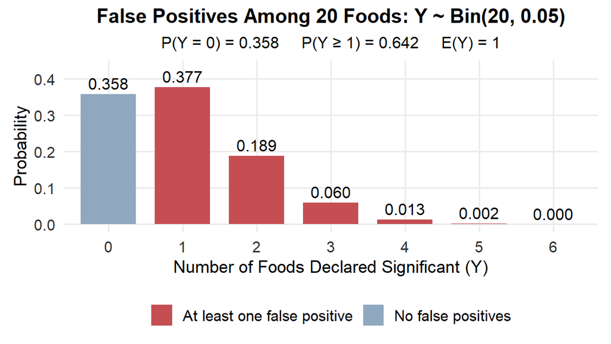

There is about a $64\%$ chance that the study reports at least one “significant” food. If the researcher then publishes only that food (for example, “Aged cheese linked to migraine, $P=0.03$”), readers see one small $P$-value and none of the $19$ non-significant tests behind it.

```r
number_of_tests <- 20
alpha <- 0.05

c(
  expected_false_positives = number_of_tests * alpha,
  p_none = dbinom(0, size = number_of_tests, prob = alpha),
  p_at_least_one = 1 - (1 - alpha)^number_of_tests
)
```

```
## expected_false_positives                   p_none           p_at_least_one
##                1.0000000                0.3584859                0.6415141
```

### 15.6.10 The Risk Grows with the Number of Tests

For $m$ independent tests of true null hypotheses at level $\alpha$,

$$P(\text{at least one false positive})=1-(1-\alpha)^m$$

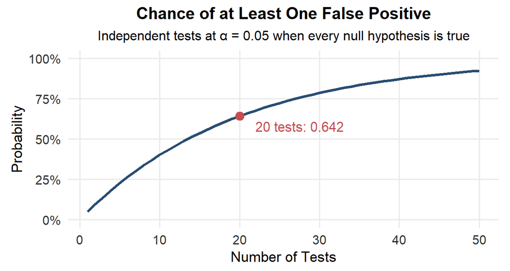

Under the illustrative independence assumption, the probability of at least one false positive increases quickly as the number of tests grows. With $20$ tests at level $\alpha=0.05$, the probability is approximately $0.642$. Dependence among tests changes the exact probability, but not the broader warning that an unreported search across many analyses inflates false-positive risk.

### 15.6.11 Example 15.6 (continued): Controlling the Overall Error Rate

One simple remedy is the **Bonferroni adjustment**: test each of the $m$ hypotheses at level $\alpha/m$. For the migraine study,

$$\frac{0.05}{20}=0.0025$$

and the probability of at least one false positive becomes

$$1-(1-0.0025)^{20}\approx0.049$$

which is back below $0.05$ for the whole family of tests. The cost is that each individual test now requires much stronger evidence, which lowers its power (Section 15.7).

```r
1 - (1 - 0.05 / 20)^20
```

```
## [1] 0.04883012
```

### 15.6.12 Selective Reporting, Replication and Transparency

**P-hacking** or **data dredging** occurs when researchers try many outcomes, subgroups or models and emphasize only analyses that produce small $P$-values.

**Selective reporting** occurs when nonsignificant findings are omitted.

**Publication bias** occurs when studies with significant results are more likely to become publicly available than studies with nonsignificant results.

These practices distort the published evidence in exactly the way Example 15.6 illustrates.

Replication repeats a study with new observations and an independently specified analysis. A successful replication reduces the chance that the original finding depended on an unusual sample, an unnoticed design problem or a flexible analysis decision. If the aged-cheese result in Example 15.6 were a false positive, a new study testing only aged cheese would have just a $5\%$ chance of producing another significant result.

Useful scientific practices include

- Stating the research question and analysis plan before examining results
- Reporting all planned outcomes and analyses
- Reporting estimates and uncertainty in addition to $P$-values
- Distinguishing exploratory analyses from confirmatory analyses
- Sharing enough methodological information for others to evaluate or reproduce the work

One study rarely settles an important scientific question. Evidence becomes stronger when results remain consistent across well-designed studies using different samples and settings.

## 15.7 Errors and Power

Section 15.6 described false positives. A test can also make the opposite mistake: missing an effect that is really there. This section names both errors, shows how to calculate their probabilities from sampling distributions and introduces power.

### 15.7.1 Type I and Type II Errors

A hypothesis-test decision can be correct or incorrect.

| Decision | $H_0$ is true | A specified alternative is true |
| --- | --- | --- |
| Fail to reject $H_0$ | Correct decision | Type II error |
| Reject $H_0$ | Type I error | Correct decision |

A **Type I error** occurs when the test rejects a true null hypothesis. It is the false positive of Section 15.6.

$$P(\text{Type I error})
=
P(\text{reject }H_0\mid H_0\text{ true})
=
\alpha$$

A **Type II error** occurs when the test fails to reject $H_0$ even though a specified alternative is true. It is a false negative. Its probability is denoted by $\beta$:

$$\beta
=
P(\text{fail to reject }H_0\mid\text{a specified alternative is true})$$

The two probabilities are computed from **different** sampling distributions: $\alpha$ from the null distribution and $\beta$ from the distribution under the alternative. The value of $\beta$ depends on which alternative value is assumed.

The relative seriousness of these errors depends on context. For example, approving an ineffective treatment and failing to identify an effective treatment have different consequences.

### 15.7.2 Example 15.7: The Sweetness Study

A quality-control engineer studies whether storage reduces the sweetness of a new cola. Ten trained tasters rate the cola before and after storage. For each taster, the response is the loss of sweetness on a $10$-point scale.

The hypotheses are

$$H_0:\mu=0
\qquad
H_a:\mu>0$$

where $\mu$ is the population mean sweetness loss. The planning information is

$$\sigma=1
\qquad
n=10
\qquad
\alpha=0.05$$

A mean loss of $\mu=0.8$ point is considered large enough to matter to consumers.

To find error probabilities, the test must first be written as a **decision rule** on the scale of $\bar x$.

The test is upper-tailed. At $\alpha=0.05$, the critical Standard Normal value is $z^*=1.645$. Under $H_0:\mu=0$, the standard deviation of $\bar X$ is

$$\frac{\sigma}{\sqrt{n}}
=
\frac{1}{\sqrt{10}}
\approx
0.3162$$

The rejection cutoff for the sample mean is

$$\bar{x}_{\text{crit}}
=
\mu_0+z^*\frac{\sigma}{\sqrt n}
=
0+1.645(0.3162)
\approx
0.520$$

> **Decision rule**

> Reject $H_0$ when $\bar x\ge0.520$. Fail to reject $H_0$ when $\bar x<0.520$.

### 15.7.3 Example 15.7 (continued): The Type I Error

A Type I error happens when $\mu=0$ (storage causes no loss) but the tasters’ mean loss happens to be at least $0.520$, so the engineer concludes that storage reduces sweetness.

$$P(\text{Type I error})
=
P(\bar X\ge0.520\mid\mu=0)
=
P\left(Z\ge\frac{0.520-0}{0.3162}\right)
=
P(Z\ge1.645)
=
0.05$$

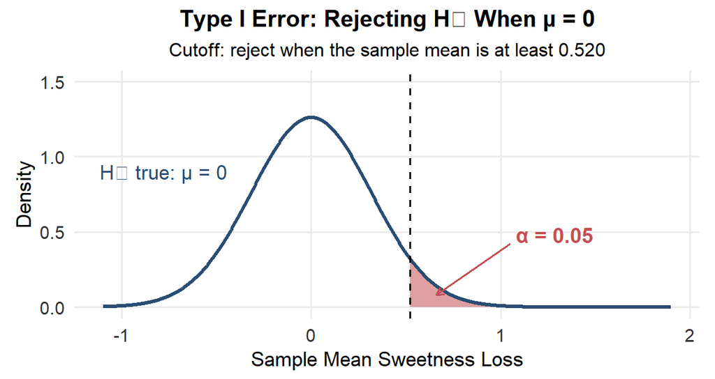

The cutoff was chosen to make this area exactly $\alpha$.

### 15.7.4 Example 15.7 (continued): The Type II Error

Now suppose storage really does cause a mean loss of $\mu=0.8$. The sampling distribution of $\bar X$ then has mean $0.8$ and the same standard deviation $0.3162$, but the decision rule does not change.

**A concrete Type II error.** Suppose the ten tasters report losses with mean $\bar x=0.45$. Because $0.45<0.520$, the engineer fails to reject $H_0$ and concludes that there is not enough evidence of a sweetness loss. If the true mean loss is $0.8$, this conclusion is a Type II error: a real and important loss has been missed. The tasters simply produced a sample mean on the low side of what $\mu=0.8$ typically produces.

**How often does this happen?** The probability of a Type II error at $\mu=0.8$ is the probability that $\bar X$ falls in the fail-to-reject region when the mean is $0.8$:

$$\beta
=
P(\bar X<0.520\mid\mu=0.8)
=
P\left(Z<\frac{0.520-0.8}{0.3162}\right)
=
P(Z<-0.885)
\approx
0.188$$

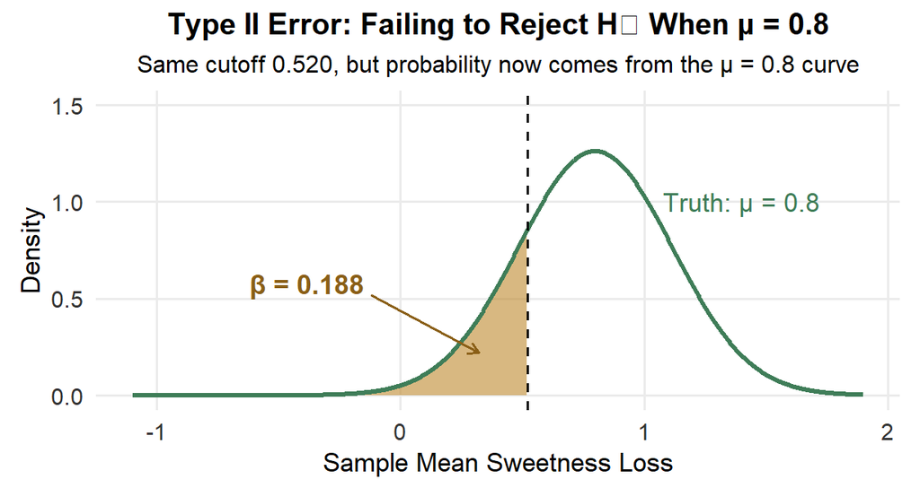

With only $10$ tasters, about $18.8\%$ of studies would miss a real mean loss of $0.8$ point. The calculation uses the same cutoff as the Type I error calculation, but the area now comes from the curve centred at $\mu=0.8$.

### 15.7.5 Power

The **power** of a test against a specified alternative is the probability that the test rejects $H_0$ when that alternative is true.

$$\text{Power}
=
P(
\text{reject }H_0
\mid
\text{specified alternative is true}
)$$

Rejecting and failing to reject are complementary events, so

$$\boxed{
\text{Power}=1-\beta
}$$

For the sweetness study at $\mu=0.8$,

$$\text{Power}
=
P(\bar X\ge0.520\mid\mu=0.8)
=
P(Z\ge-0.885)
\approx
0.812$$

The test will reject $H_0$ in approximately $81.2\%$ of repeated studies when the true population mean loss is $0.8$ point.

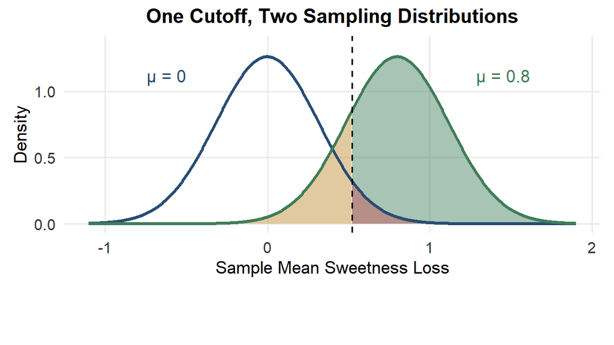

In the graph, the area to the right of the cutoff under the null distribution is $\alpha=0.05$. Under the alternative distribution, the area to the left of the cutoff is $\beta=0.188$ and the area to the right is the power $0.812$.

The calculation can be checked in R.

```r
sigma <- 1
n <- 10
alpha <- 0.05
mu_0 <- 0
mu_alternative <- 0.8

standard_deviation_xbar <- sigma / sqrt(n)
critical_x_bar <- qnorm(
  1 - alpha,
  mean = mu_0,
  sd = standard_deviation_xbar
)

beta <- pnorm(
  critical_x_bar,
  mean = mu_alternative,
  sd = standard_deviation_xbar
)

c(
  critical_sample_mean = critical_x_bar,
  beta = beta,
  power = 1 - beta
)
```

```
## critical_sample_mean                 beta                power
##            0.5201484            0.1880868            0.8119132
```

In context:

- A Type I error means concluding that storage causes a population mean sweetness loss when the true mean loss is $0$
- A Type II error at $\mu=0.8$ means failing to detect a mean loss of $0.8$ point when that loss is real

### 15.7.6 Power Depends on the Alternative

Power is always defined for a particular alternative value. A test does not have one universal power value. Repeating the calculation for several true means gives

| True mean loss $\mu$ | Power $=P(\bar X\ge0.520\mid\mu)$ | $\beta$ |
| --- | --- | --- |
| $0.3$ | $0.243$ | $0.757$ |
| $0.5$ | $0.475$ | $0.525$ |
| $0.8$ | $0.812$ | $0.188$ |
| $1.0$ | $0.935$ | $0.065$ |

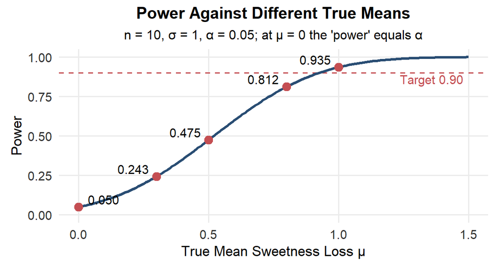

The farther the true mean lies from the null value, the easier it is to detect and the smaller the Type II error probability. At $\mu=0$ the curve equals $\alpha=0.05$, because “rejecting” there is a Type I error.

```r
mu_values <- c(0.3, 0.5, 0.8, 1.0)
power_values <- 1 - pnorm(critical_x_bar, mean = mu_values, sd = standard_deviation_xbar)

data.frame(
  mu = mu_values,
  power = round(power_values, 3),
  beta = round(1 - power_values, 3)
)
```

```
##    mu power  beta
## 1 0.3 0.243 0.757
## 2 0.5 0.475 0.525
## 3 0.8 0.812 0.188
## 4 1.0 0.935 0.065
```

The engineer wanted power of at least $0.90$ against $\mu=0.8$. With $10$ tasters the power is only $0.812$, so the study is too small. Section 15.8 finds the required number of tasters.

### 15.7.7 Example 15.8: Type II Error with a Binomial Model

Type II errors are not limited to Normal models. Return to the veterinary study of Example 15.3, where $H_0:p=0.80$ and $H_a:p<0.80$ with $n=60$ dogs.

**Step 1: Decision rule.** Rejection happens for small counts. The largest cutoff $k$ with $P(X\le k\mid p=0.80)\le0.05$ is $k=42$:

$$P(X\le42\mid p=0.80)\approx0.0427
\qquad
P(X\le43\mid p=0.80)\approx0.0772$$

The rule is: reject $H_0$ when $X\le42$. Because $X$ is discrete, the actual Type I error probability is $0.0427$, slightly below the nominal $0.05$.

**Step 2: A concrete Type II error.** Suppose the treatment’s true response probability is only $p=0.70$, a clinically important shortfall. A second clinic treats $60$ dogs and observes $X=45$ responses. Because $45>42$, the clinic fails to reject $H_0$ (the exact $P$-value is $P(X\le45\mid p=0.80)\approx0.207$). The treatment really falls short, but the study does not detect it. This is a Type II error.

**Step 3: Probability of a Type II error.** Under $p=0.70$, the count follows $\operatorname{Bin}(60,0.70)$, so

$$\beta
=
P(X\ge43\mid p=0.70)
=
1-P(X\le42\mid p=0.70)
\approx
1-0.549
=
0.451$$

and the power against $p=0.70$ is about $0.549$.

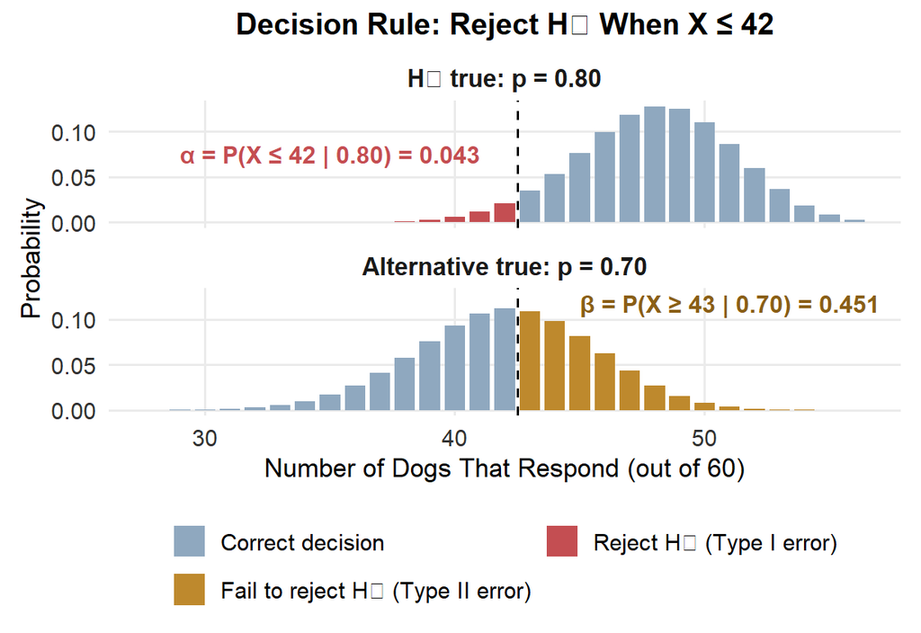

The top panel shows the Type I error probability under the null model and the bottom panel shows the Type II error probability under the alternative. With $60$ dogs, a shortfall from $0.80$ to $0.70$ would be missed nearly half the time.

```r
cdf_null <- pbinom(0:60, size = 60, prob = 0.80)
k <- max(which(cdf_null <= 0.05)) - 1   # largest k with P(X <= k) <= 0.05

c(
  cutoff_k = k,
  actual_alpha = pbinom(k, size = 60, prob = 0.80),
  beta_p_0.70 = 1 - pbinom(k, size = 60, prob = 0.70),
  power_p_0.70 = pbinom(k, size = 60, prob = 0.70)
)
```

```
##     cutoff_k actual_alpha  beta_p_0.70 power_p_0.70
##   42.0000000    0.0426973    0.4514363    0.5485637
```

### 15.7.8 What Affects Power

The calculations above show which features of a study change power. Power increases when

- The sample size increases (the sampling distributions become narrower and overlap less)
- The true effect is farther from the null value
- The population variability $\sigma$ is smaller
- The significance level $\alpha$ is larger (the cutoff moves toward $\mu_0$, at the cost of more Type I errors)
- A one-sided test is justified instead of a two-sided test

For a fixed sample size, lowering $\alpha$ reduces Type I errors but increases Type II errors. Increasing the sample size is the main way to reduce both.

## 15.8 Planning Studies: Selecting a Sample Size

Sections 15.4 and 15.7 showed that sample size controls both the precision of a confidence interval and the power of a test. Study planning uses those relationships in reverse: it chooses $n$ before data collection so the study can answer its question.

Larger samples provide more information, but collecting observations may require time, money, specialized equipment or participant risk. A useful design balances statistical performance with practical and ethical constraints.

### 15.8.1 Sample Size for a Desired Margin of Error

For a one-sample $z$ confidence interval,

$$m
=
z^*\frac{\sigma}{\sqrt{n}}$$

To find the sample size required for a desired margin of error, solve for $n$.

First divide by $z^*\sigma$:

$$\frac{m}{z^*\sigma}
=
\frac{1}{\sqrt{n}}$$

Invert both sides:

$$\frac{z^*\sigma}{m}
=
\sqrt{n}$$

Square both sides:

$$\boxed{
n
=
\left(
\frac{z^*\sigma}{m}
\right)^2
}$$

The result must always be rounded **up**. Rounding down would produce a margin of error slightly larger than the target.

### 15.8.2 Inputs to the Sample-Size Formula

The formula requires three planning quantities.

| Quantity | Meaning | Planning source |
| --- | --- | --- |
| $z^*$ | Critical value for the chosen confidence level | Standard Normal table or software |
| $\sigma$ | Anticipated population standard deviation | Previous research, pilot data or a conservative estimate |
| $m$ | Largest acceptable margin of error | Scientific or practical precision requirement |

A poor estimate of $\sigma$ can make the planned sample too small or unnecessarily large. When uncertainty about $\sigma$ is substantial, a conservative value or sensitivity analysis can be used.

### 15.8.3 Example 15.9: Planning a Body-Temperature Study

Researchers want to estimate the population mean body temperature of healthy adults within

$$m=0.05^\circ\text{F}$$

at $95\%$ confidence. Previous research suggests

$$\sigma=0.6^\circ\text{F}$$

The $95\%$ critical value is $z^*=1.960$. Substitute into the sample-size formula:

$$n
=
\left(
\frac{1.960(0.6)}{0.05}
\right)^2
=
(23.52)^2
=
553.1904$$

The value is rounded up:

$$\boxed{n=554}$$

At least $554$ healthy adults are required to ensure that the planned margin of error is no greater than $0.05^\circ$F under the stated model.

The calculation can be checked in R.

```r
z_star <- qnorm(0.975)
sigma <- 0.6
target_margin <- 0.05

unrounded_n <- (z_star * sigma / target_margin)^2
required_n <- ceiling(unrounded_n)

c(
  unrounded_sample_size = unrounded_n,
  required_sample_size = required_n
)
```

```
## unrounded_sample_size  required_sample_size
##              553.1701              554.0000
```

The achieved margin of error with $n=554$ is

```r
achieved_margin <- z_star * sigma / sqrt(required_n)
round(achieved_margin, 5)
```

```
## [1] 0.04996
```

### 15.8.4 Why Population Size Usually Does Not Appear

The usual formula depends on the confidence level, variability and desired precision. It does not depend on the size of the population when the population is much larger than the sample.

For example, the sample size needed to estimate a mean with a particular margin of error can be similar for populations of $100{,}000$ and $10{,}000{,}000$ individuals when

- Both populations have comparable variability
- The same probability-sampling design is used
- The sample is a small fraction of each population

When the sample represents a substantial fraction of a finite population, a finite-population correction can reduce the required sample size. That adjustment is beyond the one-sample formula used here.

### 15.8.5 Planning a Hypothesis Test

Planning a hypothesis test requires more than choosing a sample size. The design must specify

1. **Significance level $\alpha$:** the tolerated long-run probability of a Type I error when $H_0$ is true
2. **Effect size:** the smallest departure from the null value that would matter in context
3. **Power:** the desired probability that the test will detect that effect (equivalently, the tolerated $\beta$)

The effect size should be chosen using scientific or practical reasoning rather than from the observed data of the planned study.

### 15.8.6 Example 15.7 (continued): How Many Tasters Are Needed?

The sweetness test with $10$ tasters had power $0.812$ against $\mu=0.8$, below the target of $0.90$.

For a one-sided $z$ test, the power requirement means the cutoff $\mu_0+z_{1-\alpha}\,\sigma/\sqrt n$ must lie $z_{\text{power}}$ standard deviations below the alternative mean $\mu_0+\delta$:

$$\mu_0 + z_{1-\alpha}\frac{\sigma}{\sqrt n}
=
\mu_0+\delta - z_{\text{power}}\frac{\sigma}{\sqrt n}$$

Solving for $n$ gives the Normal-theory planning formula

$$n
=
\left(
\frac{(z_{1-\alpha}+z_{\text{power}})\sigma}{\delta}
\right)^2$$

where $\delta$ is the effect size to be detected, $z_{1-\alpha}$ is the upper-$\alpha$ critical value and $z_{\text{power}}$ is the Standard Normal value with area equal to the target power to its left.

Using

$$\alpha=0.05
\qquad
\text{power}=0.90
\qquad
\sigma=1
\qquad
\delta=0.8$$

gives

$$n
=
\left(
\frac{(1.645+1.282)(1)}{0.8}
\right)^2
\approx
13.38$$

Therefore, at least

$$\boxed{n=14}$$

tasters are required under this planning model. With $n=14$, the cutoff is $1.645/\sqrt{14}\approx0.440$ and the power against $\mu=0.8$ is $P(Z\ge(0.440-0.8)\sqrt{14})=P(Z\ge-1.35)\approx0.911$.

```r
alpha <- 0.05
target_power <- 0.90
sigma <- 1
effect_size <- 0.8

z_alpha <- qnorm(1 - alpha)
z_power <- qnorm(target_power)

unrounded_n <- (
  (z_alpha + z_power) * sigma / effect_size
)^2

required_n <- ceiling(unrounded_n)

# Check the achieved power with the rounded sample size
achieved_power <- 1 - pnorm(z_alpha - effect_size * sqrt(required_n) / sigma)

c(
  unrounded_n = unrounded_n,
  required_n = required_n,
  achieved_power = achieved_power
)
```

```
##    unrounded_n     required_n achieved_power
##     13.3810115     14.0000000      0.9112467
```

### 15.8.7 Factors That Affect Required Sample Size

| Planning change | Effect on required sample size |
| --- | --- |
| Smaller $\alpha$ | Increases required $n$ |
| Higher target power | Increases required $n$ |
| Smaller effect to detect | Increases required $n$ |
| Larger $\sigma$ | Increases required $n$ |
| Two-sided rather than one-sided test | Usually increases required $n$ |

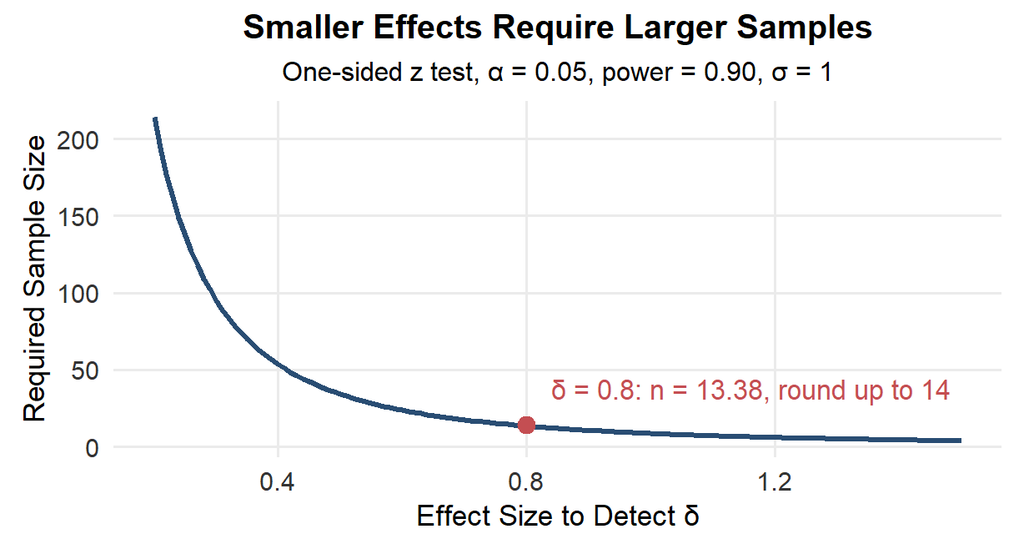

The curve illustrates the trade-off between the effect size a study is designed to detect and the required sample size. Because $n$ is proportional to $1/\delta^2$, halving the effect size to be detected multiplies the required sample size by about four. For the sweetness-study planning values, an effect of $0.8$ point requires $14$ tasters after rounding up.

## 15.9 Chapter Summary

Reliable statistical inference requires the procedure, study design and scientific question to fit one another.

### 15.9.1 Probability Foundations

- Probability models describe the outcomes that could occur under stated assumptions
- Sampling distributions connect those models to statistics such as $\bar{x}$, $\hat p$ and event counts
- Complements, disjoint-event addition, conditional probability and independence appear directly in inferential calculations
- The response and study design determine whether a Normal, binomial, Poisson or another probability model is appropriate
- Exact calculations retain the original discrete model; Normal approximations require adequate conditions
- A $P$-value has the form $P(\text{data at least as extreme as observed}\mid H_0)$, not $P(H_0\mid\text{data})$

### 15.9.2 Conditions for Inference

- Random sampling supports population generalization
- Random assignment supports causal treatment comparisons
- Nonresponse, attrition and measurement problems can weaken an otherwise sound design
- Complex sampling designs require methods that account for their structure
- Graphs, sample size and subject-matter knowledge help assess distributional conditions
- Outliers can strongly affect inference based on the sample mean

### 15.9.3 Confidence Intervals

For a one-sample $z$ interval,

$$\bar{x}
\pm
z^*\frac{\sigma}{\sqrt{n}}
\qquad\text{with}\qquad
m
=
z^*\frac{\sigma}{\sqrt{n}}$$

- A $95\%$ procedure captures the parameter in about $95\%$ of repeated samples
- Higher confidence and greater variability increase the margin of error
- Larger samples decrease it according to the square-root relationship, while the confidence level stays fixed

The margin of error measures random sampling variation under the model. It does not measure bias from poor sampling, nonresponse, confounding or systematic measurement error.

### 15.9.4 Hypothesis Tests and Significance

- A $P$-value is a tail probability from the null distribution, which may be Normal, binomial, Poisson or another model
- The alternative hypothesis determines which tail is used
- Statistical significance depends on the observed effect, population variability and sample size
- A small $P$-value does not give the probability that $H_0$ is true, measure the effect size or determine practical importance
- With $m$ independent tests of true nulls, the number of false positives is $\operatorname{Bin}(m,\alpha)$ and $P(\text{at least one})=1-(1-\alpha)^m$

### 15.9.5 Errors and Power

- Type I error: reject a true $H_0$; probability $\alpha$, calculated under $H_0$
- Type II error: fail to reject $H_0$ when a specified alternative is true; probability $\beta$, calculated under that alternative
- $\text{Power}=1-\beta$, and it depends on the alternative, $n$, $\sigma$ and $\alpha$

### 15.9.6 Study Planning

For a desired confidence-interval margin of error,

$$n
=
\left(
\frac{z^*\sigma}{m}
\right)^2$$

and for a one-sided $z$ test with target power,

$$n
=
\left(
\frac{(z_{1-\alpha}+z_{\text{power}})\sigma}{\delta}
\right)^2$$

Both results are rounded up. Statistical planning should occur before data collection so that the study has a reasonable chance of answering its scientific question.

### 15.9.7 A Consistent Workflow

1. Define the population, parameter and scientific question.
2. Examine how the data were collected.
3. Match the response to a probability model and check independence, distributional conditions and unusual observations.
4. Choose the statistic and determine its sampling distribution.
5. Report the estimate, confidence interval and exact $P$-value when appropriate.
6. Distinguish statistical evidence from practical importance.
7. Consider the error probabilities and power of the design.
8. Describe limitations and the scope of the conclusion, and replicate important findings when possible.